# final

## Creating necessary functions and loading in data

```python
import os
from tqdm import tqdm
import pandas as pd
import numpy as np
import matplotlib.pyplot as plt
from scipy.io import wavfile
from python_speech_features import mfcc, logfbank
try:  # SciPy >= 0.19
    from scipy.special import comb, logsumexp
except ImportError:
    from scipy.misc import comb, logsumexp  # noqa
import librosa
```

Creating functions for plotting the signals in different forms

```python
def plot_signals(signals,colors):
    fig, axes = plt.subplots(nrows=2, ncols=5, sharex=False,
                             sharey=True, figsize=(20,5))
    fig.suptitle('Time Series', size=16)
    i = 0
    for x in range(2):
        for y in range(5):
            axes[x,y].set_title(list(signals.keys())[i])
            axes[x,y].plot(list(signals.values())[i], color = colors[i])
            axes[x,y].get_xaxis().set_visible(False)
            axes[x,y].get_yaxis().set_visible(False)
            i += 1
```

```python
def plot_fft(fft,colors):
    fig, axes = plt.subplots(nrows=2, ncols=5, sharex=False,
                             sharey=True, figsize=(20,5))
    fig.suptitle('Fourier Transforms', size=16)
    i = 0
    for x in range(2):
        for y in range(5):
            data = list(fft.values())[i]
            Y, freq = data[0], data[1]
            axes[x,y].set_title(list(fft.keys())[i])
            axes[x,y].plot(freq, Y, color = colors[i])
            axes[x,y].get_xaxis().set_visible(False)
            axes[x,y].get_yaxis().set_visible(False)
            i += 1
```

```python
def plot_fbank(fbank):
    fig, axes = plt.subplots(nrows=2, ncols=5, sharex=False,
                             sharey=True, figsize=(20,5))
    fig.suptitle('Filter Bank Coefficients', size=16)
    i = 0
    for x in range(2):
        for y in range(5):
            axes[x,y].set_title(list(fbank.keys())[i])
            axes[x,y].imshow(list(fbank.values())[i],
                    cmap=cm.rainbow, interpolation='nearest')
            axes[x,y].get_xaxis().set_visible(False)
            axes[x,y].get_yaxis().set_visible(False)
            i += 1
```

```python
def plot_mfccs(mfccs):
    fig, axes = plt.subplots(nrows=2, ncols=5, sharex=False,
                             sharey=True, figsize=(20,5))
    fig.suptitle('Mel Frequency Cepstrum Coefficients', size=16)
    i = 0
    for x in range(2):
        for y in range(5):
            axes[x,y].set_title(list(mfccs.keys())[i])
            axes[x,y].imshow(list(mfccs.values())[i],
                    cmap=cm.rainbow, interpolation='nearest')
            axes[x,y].get_xaxis().set_visible(False)
            axes[x,y].get_yaxis().set_visible(False)
            i += 1
```

Creating functions for calculating the fft and envelope mask

```python
def calc_fft(y,rate):
    n = len(y)
    freq = np.fft.rfftfreq(n, d=1/rate)
    Y = abs(np.fft.rfft(y)/n)
    return(Y, freq)
```

```python
def envelope(y,rate,threshhold):
    mask = []
    y = pd.Series(y).apply(np.abs)
    y_mean = y.rolling(window=int(rate/10), min_periods = 1, center = True).mean()
    for mean in y_mean:
        if mean > threshhold:
            mask.append(True)
        else:
            mask.append(False)
    return mask
```

Reading in instruments related to each wav file

```python
df = pd.read_csv("instruments.csv")
```

```python
df.set_index('fname', inplace =True)
```

Finding the average length of each instrument's audio signal

```python
for f in df.index:
    rate, signal = wavfile.read('wavfiles/'+f)
    df.at[f,'length'] = signal.shape[0]/rate
```

```python
classes = list(np.unique(df.label))
class_dist = df.groupby(['label'])['length'].mean()
```

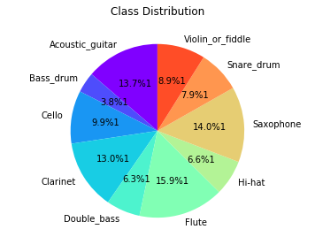

```python
import matplotlib.cm as cm
colors = cm.rainbow(np.linspace(0, 1, 11))
fig, ax = plt.subplots()
ax.set_title('Class Distribution', y=1.08)
ax.pie(class_dist, labels=class_dist.index,autopct = '%1.1f%%1',
          shadow = False, startangle = 90, colors = colors)
ax.axis('equal')
plt.show()
```

```python
df.reset_index(inplace = True)
```

## Viewing different classes

```python
signals = {}
fft = {}
fbank = {}
mfccs = {}
masks = {}
```

```python
for c in classes:
    wav_file = df[df.label == c].iloc[0,0]
    signal, rate = librosa.load('wavfiles/'+wav_file, sr = 44100)
    mask = envelope(signal, rate, 0.005)
    signals[c] = signal
    fft[c] = calc_fft(signal, rate)

    bank = logfbank(signal[:rate],rate, nfilt = 26, nfft = 1103).T
    fbank[c] = bank

    mel = mfcc(signal[:rate],rate, numcep = 26 ,nfilt = 52, nfft = 1103).T
    mfccs[c] = mel
```

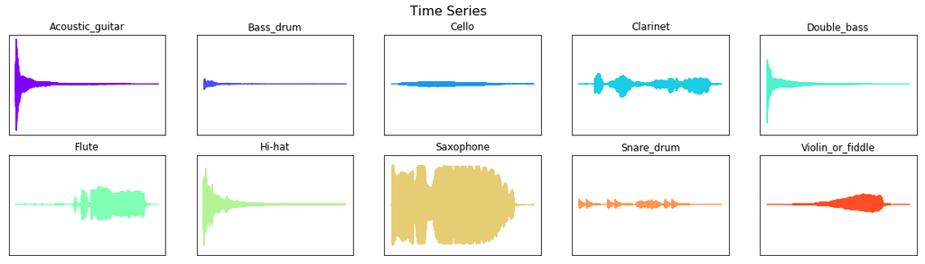

```python
plot_signals(signals,colors)
plt.show()
```

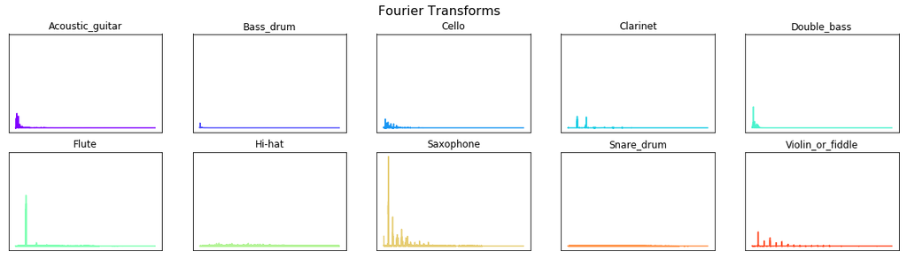

```python
plot_fft(fft, colors)
plt.show()
```

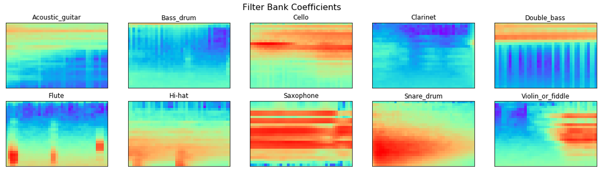

```python
plot_fbank(fbank)
plt.show()
```

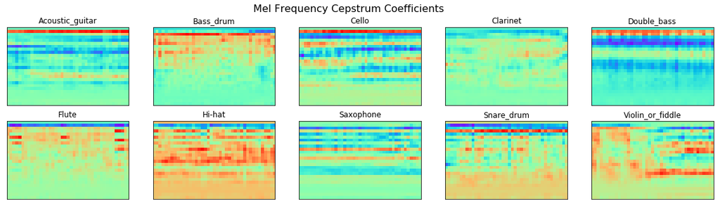

```python
plot_mfccs(mfccs)
plt.show()
```

Viewing the effects of the envelope function

```python
wav_file = df[df.label == 'Flute'].iloc[0,0]
signal_1, rate = librosa.load('wavfiles/'+wav_file, sr = 44100)

mask = envelope(signal_1, rate, 0.005)
signal = signal_1[mask]
```

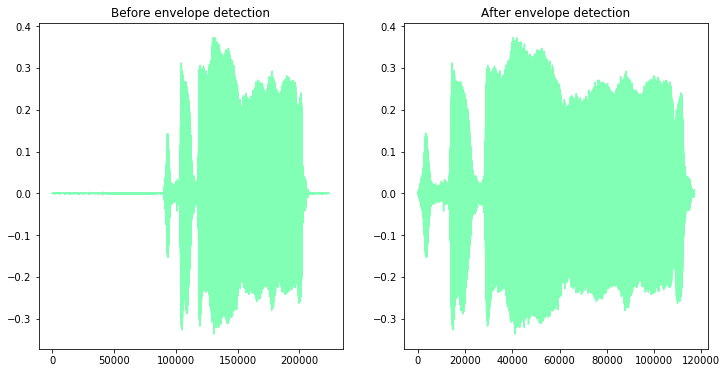

```python
plt.figure(figsize=(12, 6))
plt.subplot(1,2,1)
plt.plot(signal_1, c = colors[5])
plt.title("Before envelope detection")
plt.subplot(1,2,2)
plt.plot(signal, c = colors[5])
plt.title("After envelope detection")
plt.show()
```

## Viewing same instrument classes

```python
signals = {}
fft = {}
fbank = {}
mfccs = {}
```

```python
for i in range(0,10):
    wav_file = df[df.label == classes[0]].iloc[i,0]
    signal, rate = librosa.load('wavfiles/'+wav_file, sr = 44100)
    mask = envelope(signal, rate, 0.0005)
    signal = signal[mask]
    signals[i] = signal
    fft[i] = calc_fft(signal, rate)

    bank = logfbank(signal[:rate],rate, nfilt = 26, nfft = 1103).T
    fbank[i] = bank

    mel = mfcc(signal[:rate],rate, numcep = 13 ,nfilt = 26, nfft = 1103).T
    mfccs[i] = mel
```

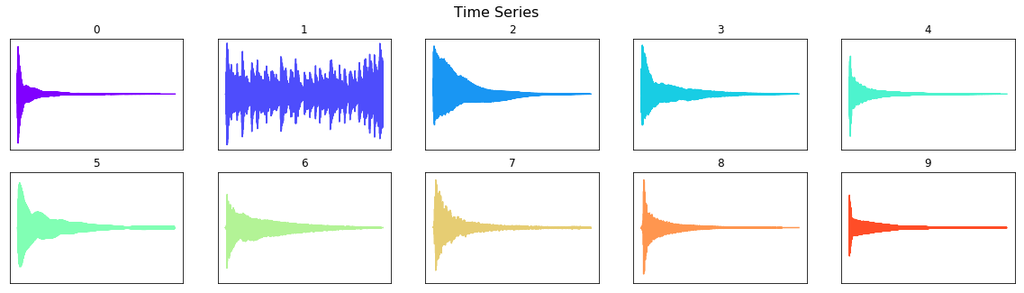

```python
plot_signals(signals,colors)
plt.show()
```

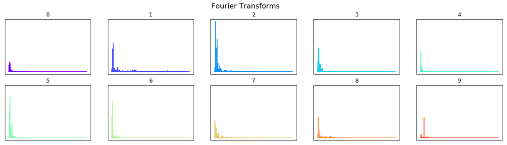

```python
plot_fft(fft,colors)
plt.show()
```

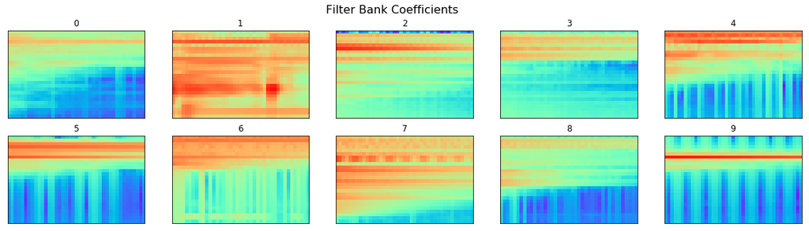

```python
plot_fbank(fbank)
plt.show()
```

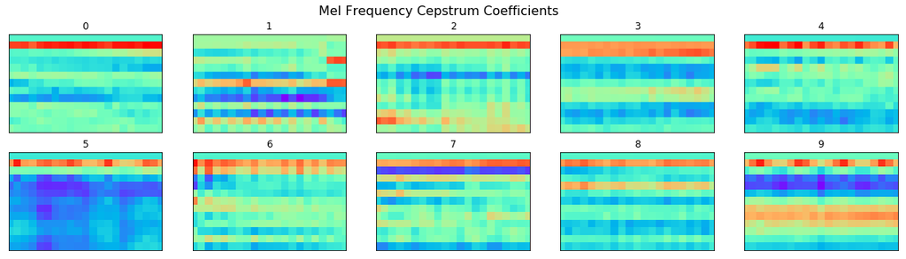

```python
plot_mfccs(mfccs)
plt.show()
```

## Cleaning data and creating a new directory

```python
if len(os.listdir("clean")) == 0:
    for f in tqdm(df.fname):
        signal, rate = librosa.load('wavfiles/'+f, sr = 16000)
        mask = envelope(signal, rate, 0.0005)
        wavfile.write(filename = 'clean/'+f, rate = rate, data = signal[mask])
```

## Modeling the data

```python
import os
from scipy.io import wavfile
import pandas as pd
import matplotlib.pyplot as plt
import numpy as np
from keras.layers import Conv2D, MaxPool2D, Flatten, LSTM
from keras.layers import Dropout, Dense, TimeDistributed
from keras.models import Sequential
from keras.utils import to_categorical
from sklearn.utils.class_weight import compute_class_weight
from tqdm import tqdm
from python_speech_features import mfcc
```

Function for creating a vector of the predominant frequency found in each fft

```python
def build_max_freq():
    max_freq = []
    for i in tqdm(range(300)):
        file = df.index[i]
        rate, wav = wavfile.read('clean/'+file)
        label = df.at[file, 'label']
        fft_vals = calc_fft(wav, rate)
        max_freq.append(round(np.array(fft_vals)[1][np.argmax(np.array(fft_vals[0]))],0))
    return max_freq
```

Function to create data observations for each audio signal

```python
def build_classes():
    X = []
    y = []
    X_red = []
    _min, _max = float('inf'), -float('inf')
    for i in tqdm(range(300)):
        file = df.index[i]
        rate, wav = wavfile.read('clean/'+file)
        label = df.at[file, 'label']
        X_sample = mfcc(wav, rate,
                       numcep=13, nfilt=26, nfft=512).T
        X_small = X_sample[:,1]
        _min = min(np.amin(X_sample), _min)
        _max = max(np.amax(X_sample), _max)
        X.append(X_sample)
        y.append(classes.index(label))
        X_red.append(X_small)
    X_red = np.array(X_red)
    X_red = (X_red - _min)/(_max - _min)
    y = to_categorical(y, num_classes=10)
    return X_red,y
```

Function to create more observations for the neural networks and configure the networks

```python
def build_rand_fest():
    X = []
    y = []
    X_red = []
    _min, _max = float('inf'), -float('inf')
    for _ in tqdm(range(n_samples)):
        rand_class = np.random.choice(class_dist.index, p=prob_dist)
        file = np.random.choice(df[df.label==rand_class].index)
        rate, wav = wavfile.read('clean/'+file)
        label = df.at[file, 'label']
        rand_index = np.random.randint(0, wav.shape[0] - config.step)
        sample = wav[rand_index:rand_index + config.step]
        X_sample = mfcc(sample, rate,
                       numcep=config.nfeat, nfilt=config.nfilt, nfft=config.nfft).T
        X_small = X_sample[:,1]
        _min = min(np.amin(X_sample), _min)
        _max = max(np.amax(X_sample), _max)
        X.append(X_sample if config.mode == 'conv' else X_sample.T)
        y.append(classes.index(label))
        X_red.append(X_small)
    X, y = np.array(X), np.array(y)
    X_red = np.array(X_red)
    X_red = (X_red - _min)/(_max - _min)
    X = (X - _min)/(_max - _min)
    if config.mode == 'conv':
        X = X.reshape(X.shape[0], X.shape[1], X.shape[2], 1)
    elif config.mode == 'time':
        X = X.reshape(X.shape[0], X.shape[1], X.shape[2])
    y = to_categorical(y, num_classes=10)
    return X,y,X_red


def get_conv_model():
    model = Sequential()
    model.add(Conv2D(16, (3,3), activation='relu', strides=(1,1),padding='same', input_shape=input_shape))
    model.add(Conv2D(32, (3,3), activation='relu', strides=(1,1),padding='same'))
    model.add(Conv2D(64, (3,3), activation='relu', strides=(1,1),padding='same'))
    model.add(Conv2D(128, (3,3), activation='relu', strides=(1,1),padding='same'))
    model.add(MaxPool2D((2,2)))
    model.add(Dropout(0.5))
    model.add(Flatten())
    model.add(Dense(128, activation='relu'))
    model.add(Dense(64, activation='relu'))
    model.add(Dense(10, activation='softmax'))
    model.summary()
    model.compile(loss='categorical_crossentropy',
                 optimizer='adam',
                 metrics=['acc'])
    return model

def get_recurrent_model():
    model = Sequential()
    model.add(LSTM(128, return_sequences=True, input_shape=input_shape))
    model.add(LSTM(128, return_sequences=True))
    model.add(Dropout(0.5))
    model.add(TimeDistributed(Dense(64, activation='relu')))
    model.add(TimeDistributed(Dense(32, activation='relu')))
    model.add(TimeDistributed(Dense(16, activation='relu')))
    model.add(TimeDistributed(Dense(8, activation='relu')))
    model.add(Flatten())
    model.add(Dense(10, activation='softmax'))
    model.summary()
    model.compile(loss='categorical_crossentropy',
                 optimizer='adam',
                 metrics=['acc'])
    return model

class Config:
    def __init__(self, mode='conv', nfilt=26, nfeat=13, nfft=512, rate=16000):
        self.mode = mode
        self.nfilt = nfilt
        self.nfft = nfft
        self.nfeat = nfeat
        self.rate = rate
        self.step = int(rate/10)
```

Building the vector of predominant frequencies

```python
df = pd.read_csv("instruments.csv")
df.set_index('fname', inplace =True)
```

```python
max_freq = build_max_freq()
```

## MDS

```python
acoustics = pd.read_csv("acoustic_characteristics.csv", sep = ";")
```

Scaling the data

```python
from sklearn import preprocessing
acoustics_scaled = preprocessing.scale(acoustics.iloc[:,1:5])
min_max_scaler = preprocessing.MinMaxScaler()
acoustic_minmax = min_max_scaler.fit_transform(acoustics.iloc[:,1:5])
```

Applying MDS to find distance mapping in 2 dimensions

```python
from sklearn.manifold import MDS
embedding = MDS(n_components=2)
X_transformed = embedding.fit_transform(acoustic_minmax)
X_transformed.shape
```

```
(10, 2)
```

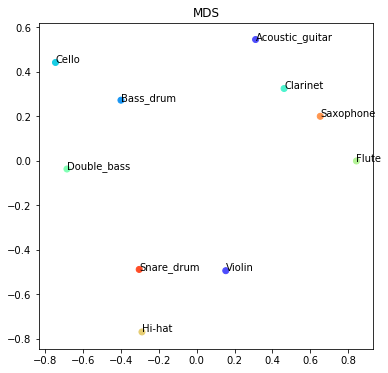

```python
colors = cm.rainbow(np.linspace(0, 1, 11))
plt.figure(figsize=(6, 6))
plt.scatter(X_transformed[:,0], X_transformed[:,1],c=colors[1:10])
for i in range(10):
    plt.annotate(acoustics.iloc[:,0][i], (X_transformed[i,0], X_transformed[i,1]))
plt.title('MDS')
plt.show()
```

```python
from sklearn.cluster import KMeans
kmeans = KMeans(n_clusters=3, random_state=0).fit(acoustic_minmax)
kmeans.labels_
```

```
array([0, 2, 2, 0, 2, 0, 1, 0, 1, 1], dtype=int32)
```

Creating vector of instrument families

```python
types = ["string","percussion","string","woodwind","string","woodwind","percussion","woodwind","percussion","string"]
type_num = [0,1,0,2,0,2,1,2,1,0]
```

Plotting the represenation coloured by k-means clusters and instrument family

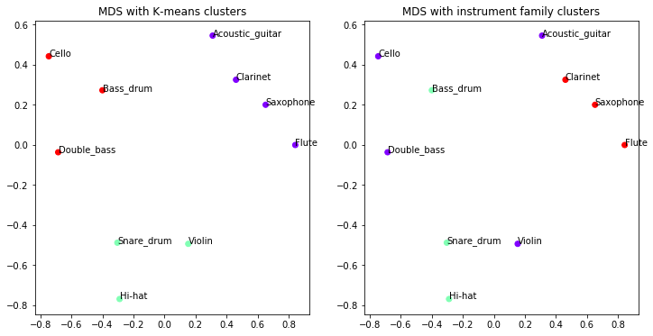

```python
import matplotlib.cm as cm
colors = cm.rainbow(np.linspace(0, 1, 3))
plt.figure(figsize=(12, 6))
plt.subplot(1,2,1)
plt.scatter(X_transformed[:,0], X_transformed[:,1], c = colors[kmeans.labels_])
for i in range(10):
    plt.annotate(acoustics.iloc[:,0][i], (X_transformed[i,0], X_transformed[i,1]))
plt.title('MDS with K-means clusters')
plt.subplot(1,2,2)
plt.scatter(X_transformed[:,0], X_transformed[:,1], c = colors[type_num])
for i in range(10):
    plt.annotate(acoustics.iloc[:,0][i], (X_transformed[i,0], X_transformed[i,1]))
plt.title('MDS with instrument family clusters')
plt.show()
```

```python
clusters_mds = [0,2,2,0,2,0,1,0,1,1]
```

## PCA

```python
X_red,y = build_classes()
```

```python
y_vec = list()

for i in range(y.shape[0]):
    for j in range(y[0].shape[0]):
        if y[i,j] == 1.0:
            y_vec.append(j+1)
```

instrument family and mds cluster numbers for all the observations

```python
family_fix = [type_num[i-1] for i in y_vec]
```

```python
cluster_fix = [clusters_mds[i-1] for i in y_vec]
```

```python
from sklearn.decomposition import PCA
pca = PCA(n_components=13)
principalComponents = pca.fit_transform(X_red)
```

Calculating variation captured and plotting scree plot

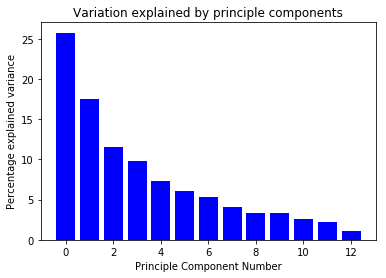

```python
np.shape(pca.explained_variance_ratio_)

plt.title('Variation explained by principle components')
plt.xlabel("Principle Component Number")
plt.ylabel("Percentage explained variance")
plt.bar(range(0,13) ,height = (pca.explained_variance_/sum(pca.explained_variance_)*100)[0:13],color = 'blue')
plt.show()
```

```python
print('variation explained', sum(pca.explained_variance_ratio_[0:13]))
print('variation explained', sum(pca.explained_variance_ratio_[0:3]))
print('variation explained', sum(pca.explained_variance_ratio_[0:2]))
```

```
variation explained 1.0000000000000002
variation explained 0.5483488591739725
variation explained 0.4324120347412661
```

Visualizing the first two components

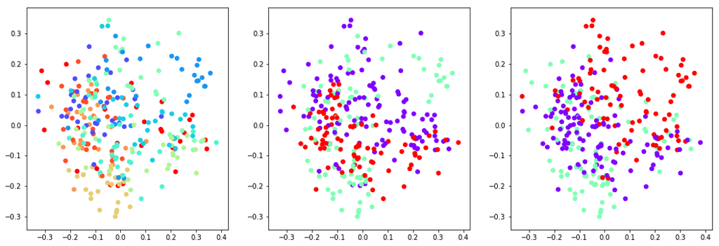

```python
colors1 = cm.rainbow(np.linspace(0, 1, 3))
colors = cm.rainbow(np.linspace(0, 1, 11))
plt.figure(figsize=(18, 6))
plt.subplot(1,3,1)
plt.scatter(principalComponents[:,0], principalComponents[:,1], c = colors[y_vec])
plt.subplot(1,3,2)
plt.scatter(principalComponents[:,0], principalComponents[:,1], c = colors1[family_fix])
plt.subplot(1,3,3)
plt.scatter(principalComponents[:,0], principalComponents[:,1], c = colors1[cluster_fix])
plt.show()
```

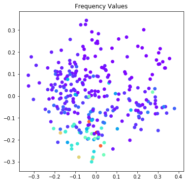

```python
colors = cm.rainbow(np.linspace(0, 1, 3))
plt.figure(figsize=(6, 6))
plt.scatter(principalComponents[:,0], principalComponents[:,1], c = max_freq, cmap = cm.rainbow)
plt.title('Frequency Values')
plt.show()
```

## Kernel PCA

```python
from sklearn.decomposition import KernelPCA
```

```python
kpca = KernelPCA(kernel='poly',n_components=13, degree = 5)
x_kpca = kpca.fit_transform(X_red)
```

Calculating variance explained and plotting scree plot

```python
explained_variance = np.var(x_kpca, axis=0)
explained_variance_ratio = explained_variance / np.sum(explained_variance)
```

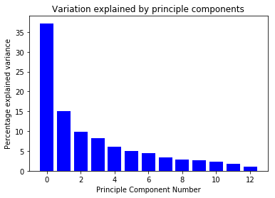

```python
plt.title('Variation explained by principle components')
plt.xlabel("Principle Component Number")
plt.ylabel("Percentage explained variance")
plt.bar(range(0,13) ,height = (explained_variance/np.sum(explained_variance)*100)[0:13],color = 'blue')
plt.show()
```

```python
print('variation explained', sum(explained_variance_ratio[0:11]))
print('variation explained', sum(explained_variance_ratio[0:3]))
print('variation explained', sum(explained_variance_ratio[0:2]))
```

```
variation explained 0.9714262966359514
variation explained 0.6207331144165221
variation explained 0.5229896644550628
```

Visualizing first two components

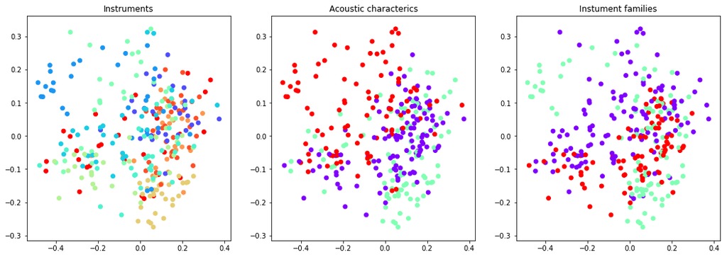

```python
colors1 = cm.rainbow(np.linspace(0, 1, 3))
colors = cm.rainbow(np.linspace(0, 1, 11))
plt.figure(figsize=(18, 6))
plt.subplot(1,3,1)
plt.scatter(x_kpca[:,0], x_kpca[:,1], c = colors[y_vec])
plt.title('Instruments')
plt.subplot(1,3,2)
plt.scatter(x_kpca[:,0], x_kpca[:,1], c = colors1[cluster_fix])
plt.title('Acoustic characterics')
plt.subplot(1,3,3)
plt.scatter(x_kpca[:,0], x_kpca[:,1], c = colors1[family_fix])
plt.title('Instument families')
plt.show()
```

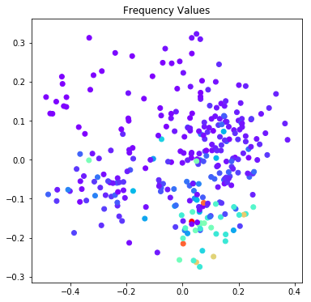

```python
colors = cm.rainbow(np.linspace(0, 1, 3))
plt.figure(figsize=(6, 6))
plt.scatter(x_kpca[:,0], x_kpca[:,1], c = max_freq, cmap = cm.rainbow)
plt.title('Frequency Values')
plt.show()
```

## TSNE

```python
from sklearn.manifold import TSNE
X_embedded = TSNE(n_components=2).fit_transform(X_red)
X_embedded.shape
```

```
(300, 2)
```

## Clustering

### Finding number of k

k-means

```python
from sklearn.datasets import make_blobs
from sklearn.metrics import pairwise_distances
from sklearn.cluster import KMeans

data = X_red

def compute_inertia(a, X):
    W = [np.mean(pairwise_distances(X[a == c, :])) for c in np.unique(a)]
    return np.mean(W)

def compute_gap(clustering, data, k_max=5, n_references=5):
    if len(data.shape) == 1:
        data = data.reshape(-1, 1)
    reference = np.random.rand(*data.shape)
    reference_inertia = []
    for k in range(1, k_max+1):
        local_inertia = []
        for _ in range(n_references):
            clustering.n_clusters = k
            assignments = clustering.fit_predict(reference)
            local_inertia.append(compute_inertia(assignments, reference))
        reference_inertia.append(np.mean(local_inertia))

    ondata_inertia = []
    for k in range(1, k_max+1):
        clustering.n_clusters = k
        assignments = clustering.fit_predict(data)
        ondata_inertia.append(compute_inertia(assignments, data))

    gap = np.log(reference_inertia)-np.log(ondata_inertia)
    return gap, np.log(reference_inertia), np.log(ondata_inertia)
```

```python
gap, reference_inertia, ondata_inertia = compute_gap(KMeans(),X_red, k_max = 10)
```

```python
from sklearn.metrics import silhouette_score
scores = []
for n_clusters in range(2,10):
    clusterer = KMeans(n_clusters=n_clusters)
    preds = clusterer.fit_predict(X_red)
    centers = clusterer.cluster_centers_
    score = silhouette_score(X_red, preds)
    scores.append(score)
```

```python
Sum_of_squared_distances = []
K = range(1,15)
for k in K:
    km = KMeans(n_clusters=k)
    km = km.fit(X_red)
    Sum_of_squared_distances.append(km.inertia_)
```

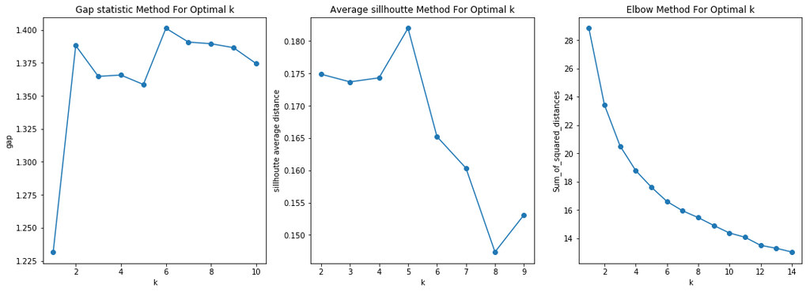

```python
plt.figure(figsize=(18,6))
plt.subplot(1,3,1)
plt.plot(range(1, 11), gap, '-o')
plt.ylabel('gap')
plt.xlabel('k')
plt.title('Gap statistic Method For Optimal k')
plt.subplot(1,3,2)
plt.plot(range(2, 10), scores, '-o')
plt.ylabel('sillhoutte average distance')
plt.xlabel('k')
plt.title('Average sillhoutte Method For Optimal k')
plt.subplot(1,3,3)
plt.plot(K, Sum_of_squared_distances, '-o')
plt.xlabel('k')
plt.ylabel('Sum_of_squared_distances')
plt.title('Elbow Method For Optimal k')
plt.show()
```

GMM

```python
from sklearn import mixture

def compute_gap_gmm( data, k_max=5, n_references=5):
    if len(data.shape) == 1:
        data = data.reshape(-1, 1)
    reference = np.random.rand(*data.shape)
    reference_inertia = []
    for k in range(1, k_max+1):
        local_inertia = []
        for _ in range(n_references):
            gmm = mixture.GaussianMixture(n_components= k, covariance_type='full',
                              max_iter=100).fit(reference)
            assignments = gmm.predict(reference)
            local_inertia.append(compute_inertia(assignments, reference))
        reference_inertia.append(np.mean(local_inertia))

    ondata_inertia = []
    for k in range(1, k_max+1):
        gmm = mixture.GaussianMixture(n_components= k, covariance_type='full',
                              max_iter=100).fit(data)
        assignments = gmm.predict(data)
        ondata_inertia.append(compute_inertia(assignments, data))

    gap = np.log(reference_inertia)-np.log(ondata_inertia)
    return gap, np.log(reference_inertia), np.log(ondata_inertia)
```

```python
gap, reference_inertia, ondata_inertia = compute_gap_gmm(X_red, k_max = 10)
```

```python
scores = []
for n_clusters in range(2,10):
    gmm = mixture.GaussianMixture(n_components=n_clusters, covariance_type='full',
                              max_iter=100).fit(X_red)
    preds = gmm.predict(X_red)
    score = silhouette_score(X_red, preds)
    scores.append(score)
```

```python
Sum_of_squared_distances = []
K = range(1,15)
for k in K:
    gmm = mixture.GaussianMixture(n_components=k, covariance_type='full',max_iter=100).fit(X_red)
    preds = gmm.predict(X_red)
    inertia = compute_inertia(preds, X_red)
    Sum_of_squared_distances.append(inertia)
```

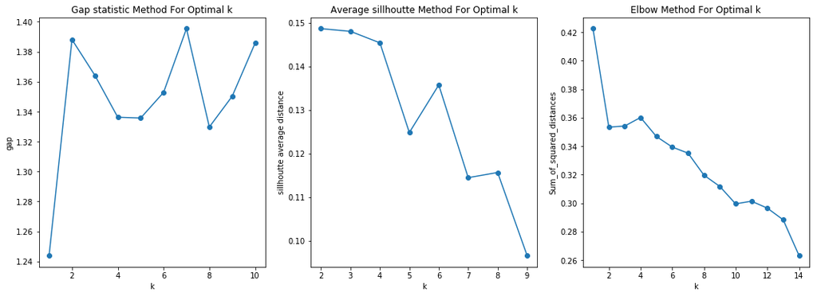

```python
plt.figure(figsize=(18,6))
plt.subplot(1,3,1)
plt.plot(range(1, 11), gap, '-o')
plt.ylabel('gap')
plt.xlabel('k')
plt.title('Gap statistic Method For Optimal k')
plt.subplot(1,3,2)
plt.plot(range(2, 10), scores, '-o')
plt.ylabel('sillhoutte average distance')
plt.xlabel('k')
plt.title('Average sillhoutte Method For Optimal k')
plt.subplot(1,3,3)
plt.plot(K, Sum_of_squared_distances, '-o')
plt.xlabel('k')
plt.ylabel('Sum_of_squared_distances')
plt.title('Elbow Method For Optimal k')
plt.show()
```

Hierarchical

```python
from sklearn.cluster import AgglomerativeClustering

def compute_gap_hier( data, k_max=5, n_references=5):
    if len(data.shape) == 1:
        data = data.reshape(-1, 1)
    reference = np.random.rand(*data.shape)
    reference_inertia = []
    for k in range(1, k_max+1):
        local_inertia = []
        for _ in range(n_references):
            cluster = AgglomerativeClustering(n_clusters=k, affinity='euclidean', linkage='ward')
            assignments = cluster.fit_predict(reference)
            local_inertia.append(compute_inertia(assignments, reference))
        reference_inertia.append(np.mean(local_inertia))

    ondata_inertia = []
    for k in range(1, k_max+1):
        cluster = AgglomerativeClustering(n_clusters=k, affinity='euclidean', linkage='ward')
        assignments = cluster.fit_predict(data)
        ondata_inertia.append(compute_inertia(assignments, data))

    gap = np.log(reference_inertia)-np.log(ondata_inertia)
    return gap, np.log(reference_inertia), np.log(ondata_inertia)
```

```python
gap, reference_inertia, ondata_inertia = compute_gap_gmm(X_red, k_max = 10)
```

```python
scores = []
for n_clusters in range(2,10):
    cluster = AgglomerativeClustering(n_clusters=n_clusters, affinity='euclidean', linkage='ward')
    preds = cluster.fit_predict(X_red)
    score = silhouette_score(X_red, preds)
    scores.append(score)
```

```python
Sum_of_squared_distances = []
K = range(1,15)
for k in K:
    cluster = AgglomerativeClustering(n_clusters=k, affinity='euclidean', linkage='ward')
    preds = cluster.fit_predict(X_red)
    inertia = compute_inertia(preds, X_red)
    Sum_of_squared_distances.append(inertia)
```

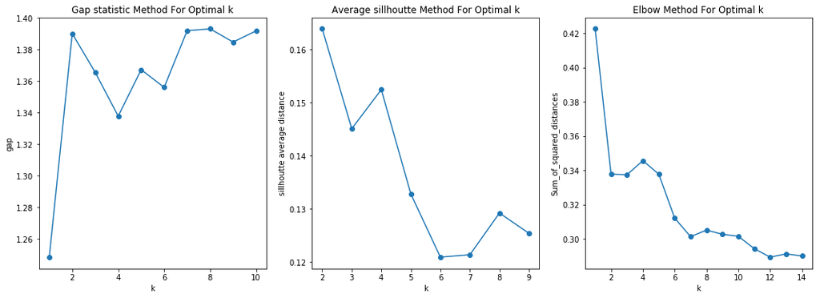

```python
plt.figure(figsize=(18,6))
plt.subplot(1,3,1)
plt.plot(range(1, 11), gap, '-o')
plt.ylabel('gap')
plt.xlabel('k')
plt.title('Gap statistic Method For Optimal k')
plt.subplot(1,3,2)
plt.plot(range(2, 10), scores, '-o')
plt.ylabel('sillhoutte average distance')
plt.xlabel('k')
plt.title('Average sillhoutte Method For Optimal k')
plt.subplot(1,3,3)
plt.plot(K, Sum_of_squared_distances, '-o')
plt.xlabel('k')
plt.ylabel('Sum_of_squared_distances')
plt.title('Elbow Method For Optimal k')
plt.show()
```

### finding 3 clusters

k-means

```python
kmeans = KMeans(n_clusters=3, random_state=0).fit(X_red)
```

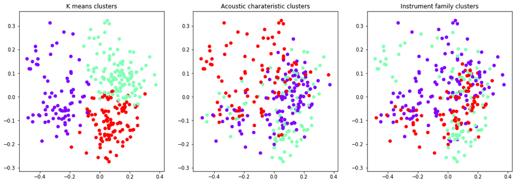

```python
colors = cm.rainbow(np.linspace(0, 1, 3))
plt.figure(figsize=(18, 6))
plt.subplot(1,3,1)
plt.scatter(x_kpca[:,0], x_kpca[:,1], c = colors[kmeans.labels_])
plt.title("K means clusters")
plt.subplot(1,3,2)
plt.scatter(x_kpca[:,0], x_kpca[:,1], c = colors[cluster_fix])
plt.title("Acoustic charateristic clusters")
plt.subplot(1,3,3)
plt.scatter(x_kpca[:,0], x_kpca[:,1], c = colors[family_fix])
plt.title("Instrument family clusters")
plt.show()
```

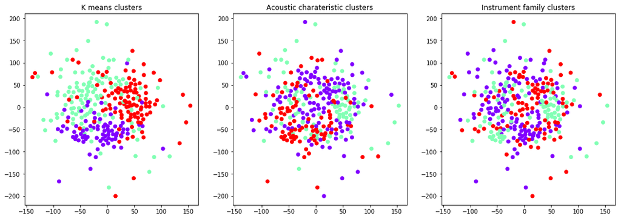

```python
colors = cm.rainbow(np.linspace(0, 1, 3))
plt.figure(figsize=(18, 6))
plt.subplot(1,3,1)
plt.scatter(X_embedded[:,0], X_embedded[:,1], c = colors[kmeans.labels_])
plt.title("K means clusters")
plt.subplot(1,3,2)
plt.scatter(X_embedded[:,0], X_embedded[:,1], c = colors[cluster_fix])
plt.title("Acoustic charateristic clusters")
plt.subplot(1,3,3)
plt.scatter(X_embedded[:,0], X_embedded[:,1], c = colors[family_fix])
plt.title("Instrument family clusters")
plt.show()
```

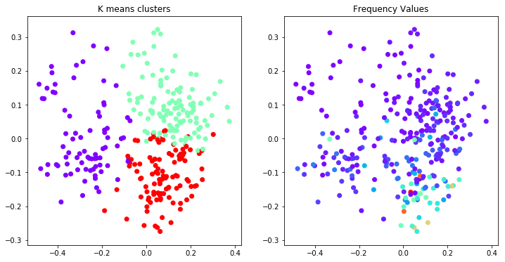

```python
colors = cm.rainbow(np.linspace(0, 1, 3))
plt.figure(figsize=(12, 6))
plt.subplot(1,2,1)
plt.scatter(x_kpca[:,0], x_kpca[:,1], c = colors[kmeans.labels_])
plt.title("K means clusters")
plt.subplot(1,2,2)
plt.scatter(x_kpca[:,0], x_kpca[:,1], c = max_freq, cmap = cm.rainbow)
plt.title("Frequency Values")
plt.show()
```

GMM

```python
gmm = mixture.GaussianMixture(n_components=3, covariance_type='full',
                              max_iter=100).fit(X_red)
```

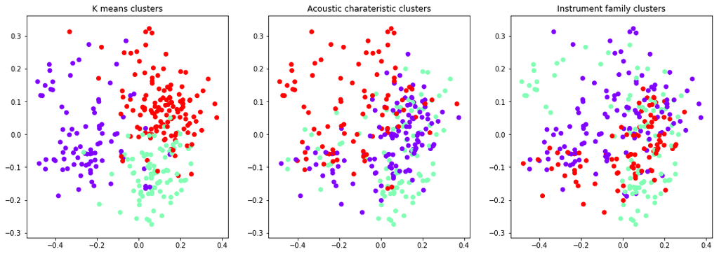

```python
colors = cm.rainbow(np.linspace(0, 1, 3))
plt.figure(figsize=(18, 6))
plt.subplot(1,3,1)
plt.scatter(x_kpca[:,0], x_kpca[:,1], c = colors[gmm.predict(X_red)])
plt.title("K means clusters")
plt.subplot(1,3,2)
plt.scatter(x_kpca[:,0], x_kpca[:,1], c = colors[cluster_fix])
plt.title("Acoustic charateristic clusters")
plt.subplot(1,3,3)
plt.scatter(x_kpca[:,0], x_kpca[:,1], c = colors[family_fix])
plt.title("Instrument family clusters")
plt.show()
```

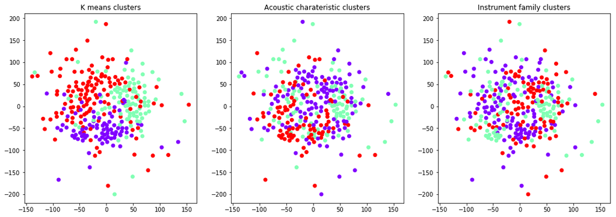

```python
colors = cm.rainbow(np.linspace(0, 1, 3))
plt.figure(figsize=(18, 6))
plt.subplot(1,3,1)
plt.scatter(X_embedded[:,0], X_embedded[:,1], c = colors[gmm.predict(X_red)])
plt.title("K means clusters")
plt.subplot(1,3,2)
plt.scatter(X_embedded[:,0], X_embedded[:,1], c = colors[cluster_fix])
plt.title("Acoustic charateristic clusters")
plt.subplot(1,3,3)
plt.scatter(X_embedded[:,0], X_embedded[:,1], c = colors[family_fix])
plt.title("Instrument family clusters")
plt.show()
```

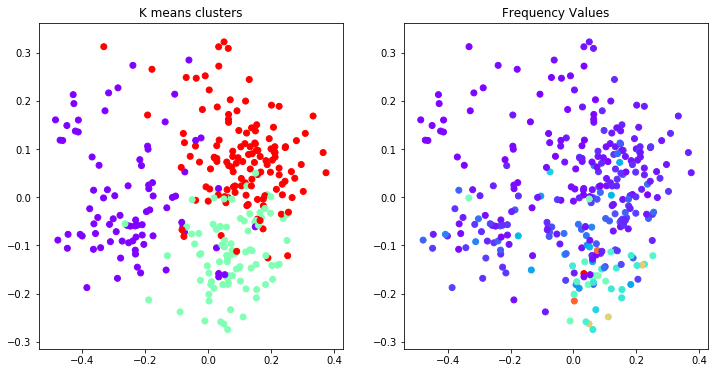

```python
colors = cm.rainbow(np.linspace(0, 1, 3))
plt.figure(figsize=(12, 6))
plt.subplot(1,2,1)
plt.scatter(x_kpca[:,0], x_kpca[:,1], c = colors[gmm.predict(X_red)])
plt.title("K means clusters")
plt.subplot(1,2,2)
plt.scatter(x_kpca[:,0], x_kpca[:,1], c = max_freq, cmap = cm.rainbow)
plt.title("Frequency Values")
plt.show()
```

Hierarchical

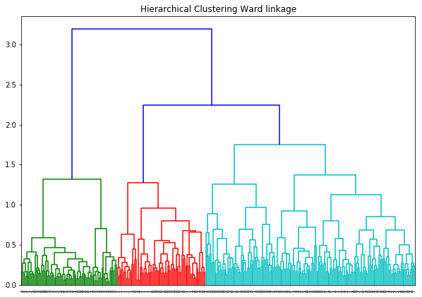

```python
from scipy.cluster.hierarchy import dendrogram, linkage

linked = linkage(X_red, 'ward')

labelList = range(1, 11)

plt.figure(figsize=(10, 7))
dendrogram(linked,
            orientation='top',
           labels=cluster_fix,
            distance_sort='descending',
            show_leaf_counts=True)
plt.title('Hierarchical Clustering Ward linkage')
plt.show()
```

```python
cluster = AgglomerativeClustering(n_clusters=3, affinity='euclidean', linkage='ward')
res = cluster.fit_predict(X_red)
```

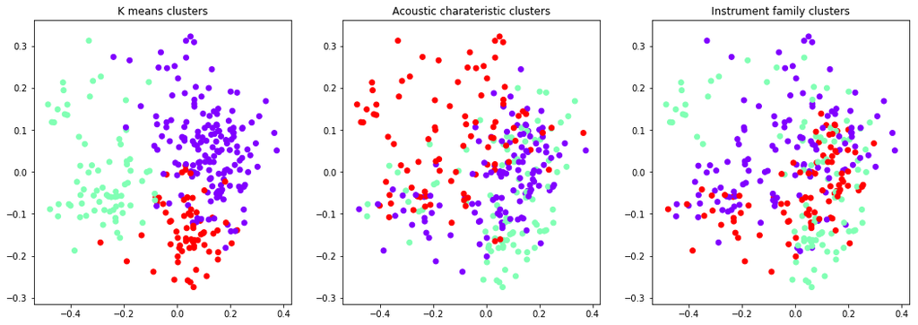

```python
colors = cm.rainbow(np.linspace(0, 1, 3))
plt.figure(figsize=(18, 6))
plt.subplot(1,3,1)
plt.scatter(x_kpca[:,0], x_kpca[:,1], c = colors[res])
plt.title("K means clusters")
plt.subplot(1,3,2)
plt.scatter(x_kpca[:,0], x_kpca[:,1], c = colors[cluster_fix])
plt.title("Acoustic charateristic clusters")
plt.subplot(1,3,3)
plt.scatter(x_kpca[:,0], x_kpca[:,1], c = colors[family_fix])
plt.title("Instrument family clusters")
plt.show()
```

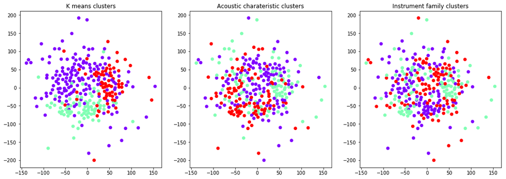

```python
colors = cm.rainbow(np.linspace(0, 1, 3))
plt.figure(figsize=(18, 6))
plt.subplot(1,3,1)
plt.scatter(X_embedded[:,0], X_embedded[:,1], c = colors[res])
plt.title("K means clusters")
plt.subplot(1,3,2)
plt.scatter(X_embedded[:,0], X_embedded[:,1], c = colors[cluster_fix])
plt.title("Acoustic charateristic clusters")
plt.subplot(1,3,3)
plt.scatter(X_embedded[:,0], X_embedded[:,1], c = colors[family_fix])
plt.title("Instrument family clusters")
plt.show()
```

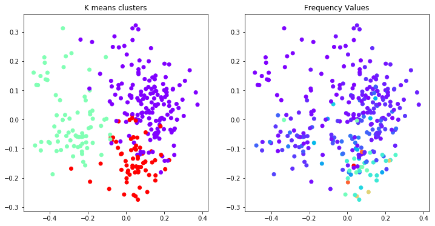

```python
colors = cm.rainbow(np.linspace(0, 1, 3))
plt.figure(figsize=(12, 6))
plt.subplot(1,2,1)
plt.scatter(x_kpca[:,0], x_kpca[:,1], c = colors[res])
plt.title("K means clusters")
plt.subplot(1,2,2)
plt.scatter(x_kpca[:,0], x_kpca[:,1], c = max_freq, cmap = cm.rainbow)
plt.title("Frequency Values")
plt.show()
```

## Classification

### Convolutional

Creating observations for classification

```python
df = pd.read_csv('instruments.csv')
df.set_index('fname', inplace=True)

for f in df.index:
    rate, signal = wavfile.read('clean/'+f)
    df.at[f, 'length'] = signal.shape[0]/rate

classes = list(np.unique(df.label))
class_dist = df.groupby(['label'])['length'].mean()
n_samples = 2 * int(df['length'].sum() / 0.1)
prob_dist = class_dist / class_dist.sum()

config = Config(mode='conv')

if config.mode == 'conv':
    X, y, X_red_all = build_rand_fest()
    y_flat = np.argmax(y, axis=1)
    input_shape =(X.shape[1], X.shape[2], 1)
    model = get_conv_model()


elif config.mode == 'time':
    X, y, X_red = build_rand_fest()
    y_flat = np.argmax(y, axis=1)
    input_shape =(X.shape[1], X.shape[2])
    model = get_recurrent_model()
```

```
_________________________________________________________________
Layer (type)                 Output Shape              Param #
=================================================================
conv2d_1 (Conv2D)            (None, 13, 9, 16)         160
_________________________________________________________________
conv2d_2 (Conv2D)            (None, 13, 9, 32)         4640
_________________________________________________________________
conv2d_3 (Conv2D)            (None, 13, 9, 64)         18496
_________________________________________________________________
conv2d_4 (Conv2D)            (None, 13, 9, 128)        73856
_________________________________________________________________
max_pooling2d_1 (MaxPooling2 (None, 6, 4, 128)         0
_________________________________________________________________
dropout_1 (Dropout)          (None, 6, 4, 128)         0
_________________________________________________________________
flatten_1 (Flatten)          (None, 3072)              0
_________________________________________________________________
dense_1 (Dense)              (None, 128)               393344
_________________________________________________________________
dense_2 (Dense)              (None, 64)                8256
_________________________________________________________________
dense_3 (Dense)              (None, 10)                650
=================================================================
Total params: 499,402
Trainable params: 499,402
Non-trainable params: 0
_________________________________________________________________
```

```python
from sklearn.model_selection import train_test_split
X_train, X_test, y_train, y_test = train_test_split(X, y, test_size=0.33, random_state=42)
```

```python
from keras.callbacks import History
history = History()

class_weight = compute_class_weight('balanced', np.unique(y_flat), y_flat)
history = model.fit(X_train,y_train, epochs=5, batch_size=32,
         shuffle=True,
         class_weight=class_weight,
         validation_split=0.2)
```

```
Train on 14155 samples, validate on 3539 samples
```

Train vs validation accuracy

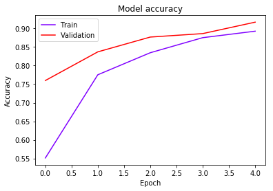

```python
plt.plot(history.history['acc'], color = colors[0])
plt.plot(history.history['val_acc'], color = colors[2])
plt.title('Model accuracy')
plt.ylabel('Accuracy')
plt.xlabel('Epoch')
plt.legend(['Train', 'Validation'], loc='upper left')
plt.show()
```

```python
y_pred = model.predict(X_test)
```

```python
y_test_vec = []

for i in range(y_test.shape[0]):
    for j in range(y_test[0].shape[0]):
        if y_test[i,j] == 1.0:
            y_test_vec.append(j+1)
```

```python
y_pred_vec = []

for i in range(y_pred.shape[0]):
    y_pred_vec.append(np.argmax(y_pred[i,:])+1)
```

Creating the confusion matrix

```python
from sklearn.metrics import confusion_matrix
conf = confusion_matrix(y_test_vec, y_pred_vec)
conf
```

```
array([[ 975,    7,   35,    4,   26,    3,    0,    6,    5,   22],
       [   0,  175,    4,    6,   10,    6,    0,    1,    0,    8],
       [  31,    7,  885,    3,   12,    9,    1,    9,    2,   13],
       [   8,    2,   12, 1073,    0,   23,    1,   12,    2,   12],
       [  34,    9,   35,    5,  456,    2,    0,    3,    2,    5],
       [  23,    1,   25,   25,    0, 1222,    1,   16,    4,   10],
       [   0,    0,    0,    0,    0,    0,  600,    1,    0,    5],
       [  19,    0,   44,    5,    0,   25,    0, 1335,    8,    9],
       [   1,    0,    3,    0,    1,    0,    1,    4,  563,    5],
       [  17,    3,   16,    5,    0,    2,    0,    9,    2,  745]])
```

```python
np.sum(np.trace(conf))/np.sum(conf)
```

```
0.9211794401101423
```